# Vizualizacija marketinških podataka portugalske banke

Tina, Josip and Mateo

1/8/2022

#ucitavanje paketa Učitajmo potrebne pakete

```r
library(dplyr)
```

#Učitavanje podataka

Učitajmo podatke iz .csv file-a

```r
BankData = read.csv("../arrangedData.csv")
dim(BankData)
```

```
## [1] 30372    15
```

Podaci se sastoje od 30 372 testiranih ljudi i 15 varijabli koje promatramo.

Popis varijabli koje promatramo:

```r
names(BankData)
```

```
##  [1] "age"            "job"            "marital"        "education"
##  [5] "default"        "housing"        "loan"           "contact"
##  [9] "month"          "day_of_week"    "duration"       "campaign"
## [13] "cons.price.idx" "cons.conf.idx"  "subscribed"
```

Za testirane sudionike u tablici su navedeni njihovi podaci (godina, posao, stanje ženidbe, edukacija…) te podaci o kreditima…(kredit za ) Možemo promotriti ponašanje varijabli.

```r
summary(BankData)
```

```
##       age            job            marital        education
##  Min.   :17.0   Min.   : 1.000   Min.   :1.000   Min.   :1.000
##  1st Qu.:31.0   1st Qu.: 1.000   1st Qu.:2.000   1st Qu.:3.000
##  Median :37.0   Median : 3.000   Median :2.000   Median :5.000
##  Mean   :39.2   Mean   : 4.779   Mean   :2.194   Mean   :4.846
##  3rd Qu.:46.0   3rd Qu.: 8.000   3rd Qu.:3.000   3rd Qu.:7.000
##  Max.   :95.0   Max.   :11.000   Max.   :3.000   Max.   :7.000
##     default            housing            loan           contact
##  Min.   :0.00e+00   Min.   :0.0000   Min.   :0.0000   Min.   :1.000
##  1st Qu.:0.00e+00   1st Qu.:0.0000   1st Qu.:0.0000   1st Qu.:1.000
##  Median :0.00e+00   Median :1.0000   Median :0.0000   Median :1.000
##  Mean   :9.88e-05   Mean   :0.5398   Mean   :0.1556   Mean   :1.321
##  3rd Qu.:0.00e+00   3rd Qu.:1.0000   3rd Qu.:0.0000   3rd Qu.:2.000
##  Max.   :1.00e+00   Max.   :1.0000   Max.   :1.0000   Max.   :2.000
##      month         day_of_week      duration         campaign
##  Min.   : 3.000   Min.   :1.00   Min.   :  35.0   Min.   : 1.000
##  1st Qu.: 5.000   1st Qu.:2.00   1st Qu.: 113.0   1st Qu.: 1.000
##  Median : 6.000   Median :3.00   Median : 190.0   Median : 2.000
##  Mean   : 6.713   Mean   :2.97   Mean   : 271.6   Mean   : 2.348
##  3rd Qu.: 8.000   3rd Qu.:4.00   3rd Qu.: 332.0   3rd Qu.: 3.000
##  Max.   :12.000   Max.   :5.00   Max.   :4918.0   Max.   :42.000
##  cons.price.idx  cons.conf.idx     subscribed
##  Min.   :92.20   Min.   :-50.8   Min.   :0.000
##  1st Qu.:93.08   1st Qu.:-42.7   1st Qu.:0.000
##  Median :93.44   Median :-41.8   Median :0.000
##  Mean   :93.52   Mean   :-40.5   Mean   :0.135
##  3rd Qu.:93.99   3rd Qu.:-36.4   3rd Qu.:0.000
##  Max.   :94.77   Max.   :-26.9   Max.   :1.000
```

```r
sapply(BankData, class)
```

```
##            age            job        marital      education        default
##      "integer"      "integer"      "integer"      "integer"      "integer"
##        housing           loan        contact          month    day_of_week
##      "integer"      "integer"      "integer"      "integer"      "integer"
##       duration       campaign cons.price.idx  cons.conf.idx     subscribed
##      "numeric"      "integer"      "numeric"      "numeric"      "integer"
```

Vidimo da su svi tipovi varijabli integer/numeric.. to je potrebno zbog klasifikacije.

Promotrimo sada kako izgledaju varijable koje dobijemo kao informaciju od ispitanika (godine, posao, ženidbeno stanje)

Histogram za godine:

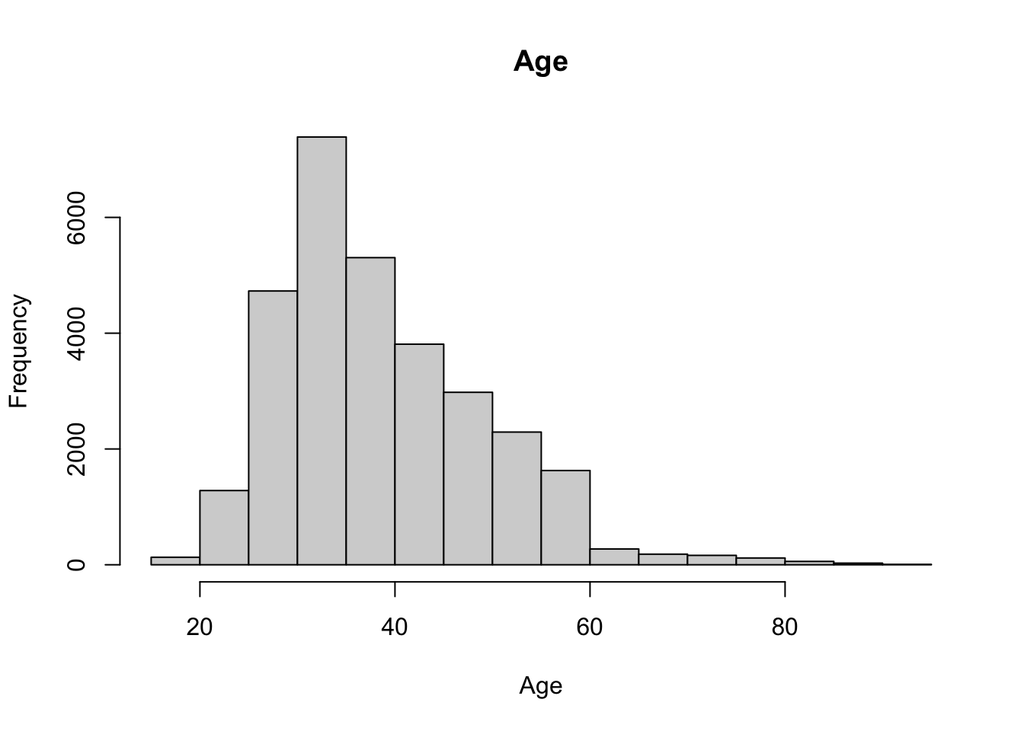

```r
hist(BankData$age,main='Age', xlab='Age', ylab='Frequency')
```

Histogram za posao: - admin:1 - bluecollar:2 - entrepreneur:3 - housemaid:4 - management:5 - retired:6 - self-employed:7 - services:8 - student:9 - technician:10 - unemployed:11

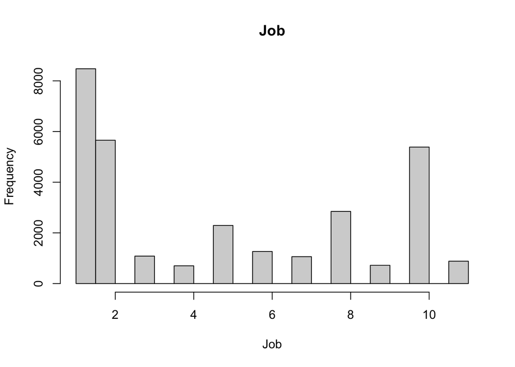

```r
hist(BankData$job,main='Job', xlab='Job', ylab='Frequency')
```

Histogram za ženidbeno stanje: - 1 = rastavljen / a - 2 = oženjen / udana - 3 = slobodan / slobodna

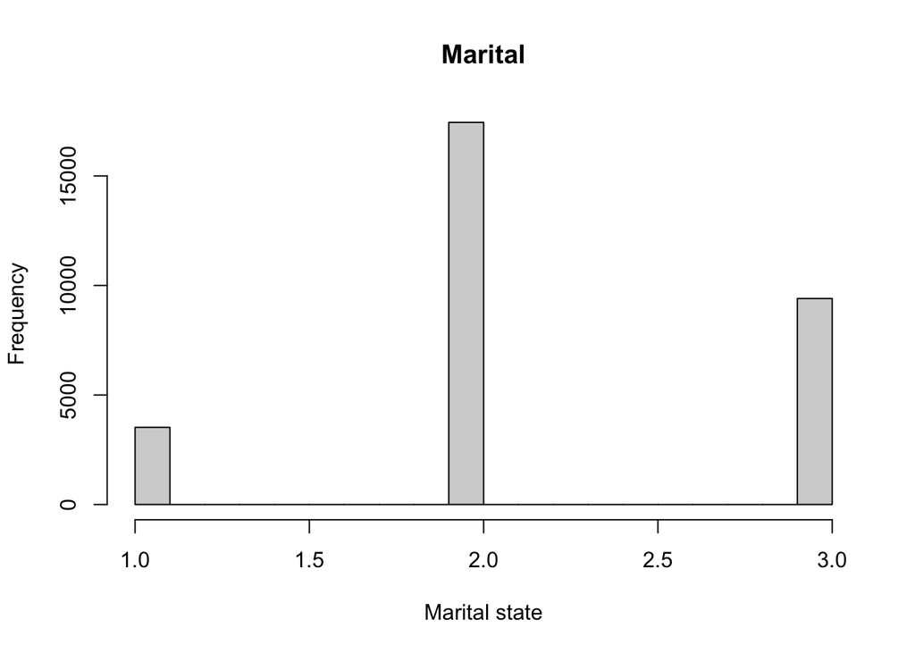

```r
hist(BankData$marital,main='Marital', xlab='Marital state', ylab='Frequency')
```

Histogram za edukaciju:

- basic.4y: 1
- basic.6y: 2
- basic.9y: 3
- high.school: 4
- illiterate: 5
- professional.course: 6
- university.degree: 7

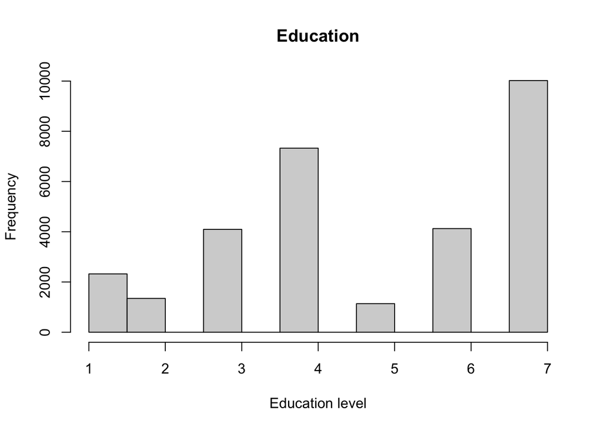

```r
hist(BankData$education,main='Education', xlab='Education level', ylab='Frequency')
```

Histogram za CPI (Consumer Price Index):

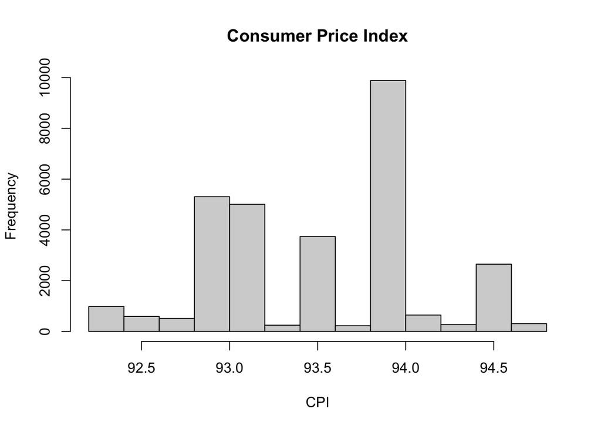

```r
hist(BankData$cons.price.idx,main='Consumer Price Index', xlab='CPI', ylab='Frequency')
```

Sada smo samo prikazali grafički neke osnovne podatke koje dobijemo za svakog ispitanika. Prateći cilj projekta, a to je da vidimo kako dani podaci ispitanika utječu na kredit osobe..

Želimo saznati kako svojstva (edukacija, dob, ženidbeni status, CPI) djeluju na status kredita, te kako kombinacije tih svojstava imaju veze.

Od kredita imamo stambeni(housing) i privatni(loan) kredit, tako da ćemo promatrati ta dva kredita odvojeno i vidjeti ima li povezanosti među njima.

Koristit ćemo box plotove, scatter plotove, histograme..

DOB:

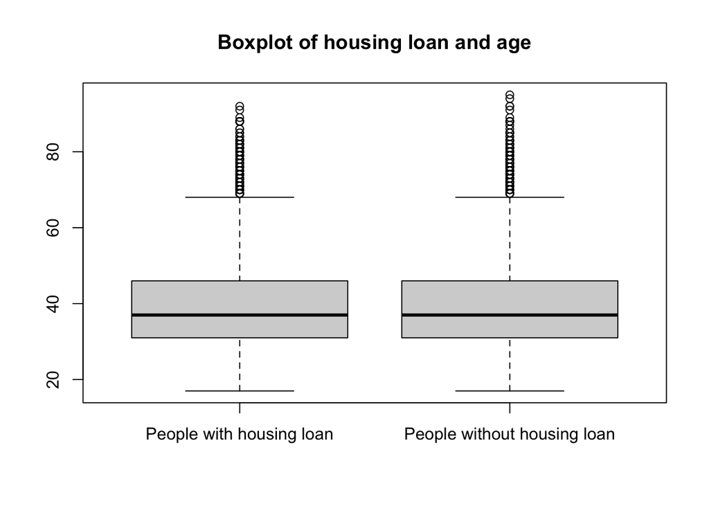

```r
#View(BankData)

people_with_housing = BankData[which(BankData$housing == 1),]
people_without_housing = BankData[which(BankData$housing == 0),]
people_with_loan = BankData[which(BankData$loan == 1),]
people_without_loan = BankData[which(BankData$loan == 0),]

young = BankData[which(BankData$age <= 18),]
middle = BankData[which(BankData$age > 18 & BankData$age <= 35),]
old = BankData[which(BankData$age > 35),]

boxplot(people_with_housing$age, people_without_housing$age,
        names = c('People with housing loan','People without housing loan'),
        main = 'Boxplot of housing loan and age')
```

Prosjeci godina ljudi s i bez stambenog kredita:

```r
cat('Prosječna dob ljudi koji imaju stambeni kredit ', mean(people_with_housing$age), '\n')
```

```
## Prosječna dob ljudi koji imaju stambeni kredit  39.22726
```

```r
cat('Prosječna dob ljudi koji nemaju stambeni kredit ', mean(people_without_housing$age), '\n')
```

```
## Prosječna dob ljudi koji nemaju stambeni kredit  39.17815
```

Prosjeci po godinama za stambeni kredit:

```r
cat('Prosječni postotak mladih ljudi koji imaju stambeni kredit ', mean(young$housing), '\n')
```

```
## Prosječni postotak mladih ljudi koji imaju stambeni kredit  0.6774194
```

```r
cat('Prosječni postotak srednje starih ljudi koji imaju stambeni kredit ', mean(middle$housing), '\n')
```

```
## Prosječni postotak srednje starih ljudi koji imaju stambeni kredit  0.5413734
```

```r
cat('Prosječni postotak starijih ljudi koji imaju stambeni kredit ', mean(old$housing), '\n')
```

```
## Prosječni postotak starijih ljudi koji imaju stambeni kredit  0.5382971
```

Prosjeci po godinama za privatni kredit:

```r
cat('Prosječni postotak mladih ljudi koji imaju privatni kredit ', mean(young$loan), '\n')
```

```
## Prosječni postotak mladih ljudi koji imaju privatni kredit  0.1612903
```

```r
cat('Prosječni postotak srednje starih ljudi koji imaju privatni kredit ', mean(middle$loan), '\n')
```

```
## Prosječni postotak srednje starih ljudi koji imaju privatni kredit  0.1614934
```

```r
cat('Prosječni postotak starijih ljudi koji imaju privatni kredit ', mean(old$loan), '\n')
```

```
## Prosječni postotak starijih ljudi koji imaju privatni kredit  0.1508134
```

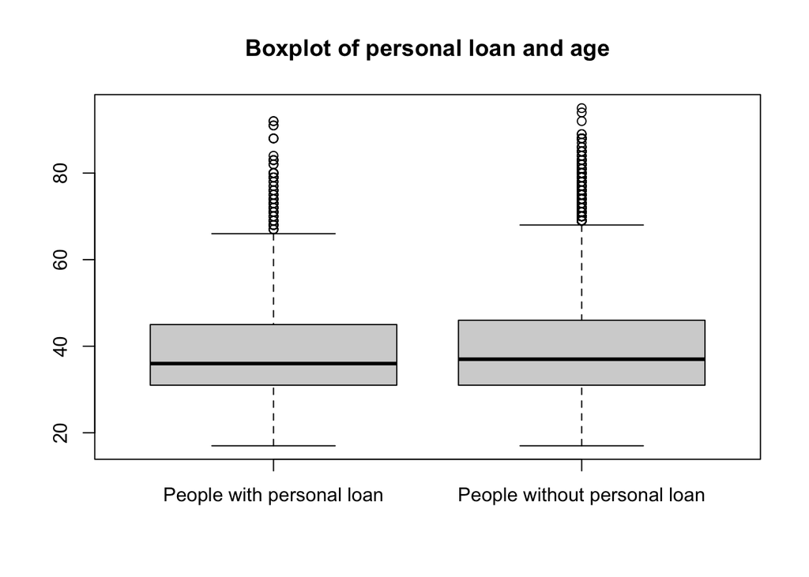

```r
boxplot(people_with_loan$age, people_without_loan$age,
        names = c('People with personal loan','People without personal loan'),
        main = 'Boxplot of personal loan and age')
```

Prosjeci godina ljudi s i bez privatnog kredita:

```r
cat('Prosječna dob ljudi koji imaju privatni kredit ', mean(people_with_loan$age), '\n')
```

```
## Prosječna dob ljudi koji imaju privatni kredit  38.96677
```

```r
cat('Prosječna dob ljudi koji nemaju privatni kredit ', mean(people_without_loan$age), '\n')
```

```
## Prosječna dob ljudi koji nemaju privatni kredit  39.24849
```

MARITAL STATUS

Podjela ispitanika ovisno o statusu ženidbe:

```r
married_people = BankData[which(BankData$marital == 2),]
divorced_and_single_people = BankData[which(BankData$marital == 1 | BankData$marital == 3),]
#single_people = BankData[which(BankData$marital == 3),]
```

Prosjeci ljudi koji imaju privatni kredit:

```r
cat('Prosjek oženjenih ljudi koji imaju privatni kredit ', mean(married_people$loan), '\n')
```

```
## Prosjek oženjenih ljudi koji imaju privatni kredit  0.1566065
```

```r
cat('Prosjek neoženjenih ljudi koji imaju privatni kredit ', mean(divorced_and_single_people$loan), '\n')
```

```
## Prosjek neoženjenih ljudi koji imaju privatni kredit  0.1541734
```

Histogram za ženidbeni status i privatni kredit:

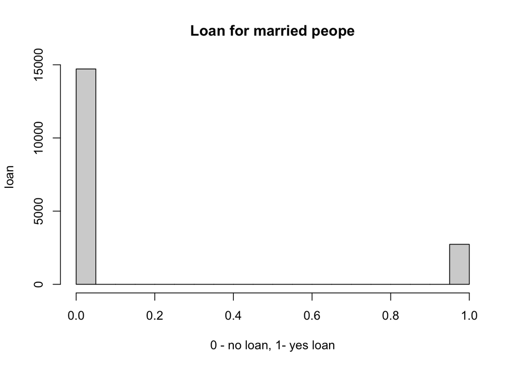

```r
hist(married_people$loan,main='Loan for married peope', xlab='0 - no loan, 1- yes loan', ylab='loan')
```

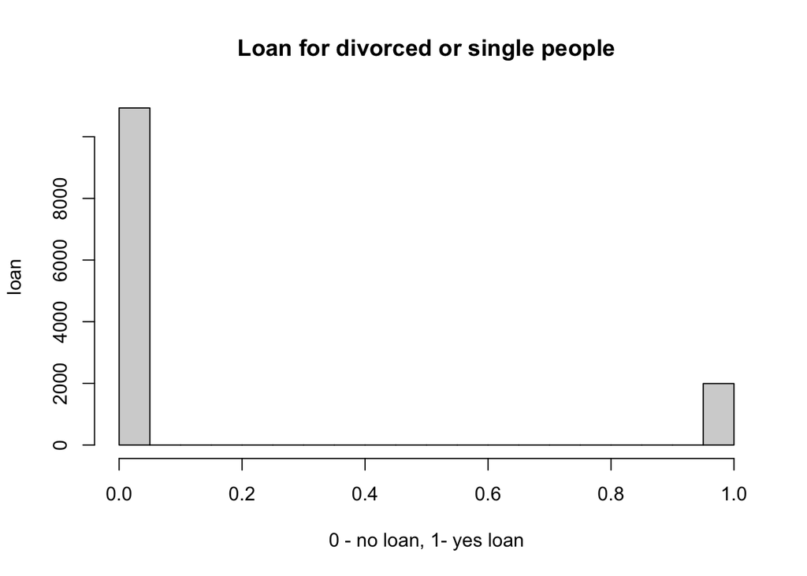

```r
hist(divorced_and_single_people$loan,main='Loan for divorced or single people', xlab='0 - no loan, 1- yes loan', ylab='loan')
```

Po danim grafovima i po izračunatim srednjim vrijednostima ne vidimo neke značajne razlike, pa za sad nećemo ništa posebno zaključivati za odnos ženidbenog statusa i privantog kredita.

Prosjeci ljudi koji imaju stambeni kredit:

```r
cat('Prosjek oženjenih ljudi koji imaju stambeni kredit ', mean(married_people$housing), '\n')
```

```
## Prosjek oženjenih ljudi koji imaju stambeni kredit  0.5363715
```

```r
cat('Prosjek neoženjenih ljudi koji imaju stambeni kredit ', mean(divorced_and_single_people$housing), '\n')
```

```
## Prosjek neoženjenih ljudi koji imaju stambeni kredit  0.5444419
```

Historam za ženidbeni status i stambeni kredit:

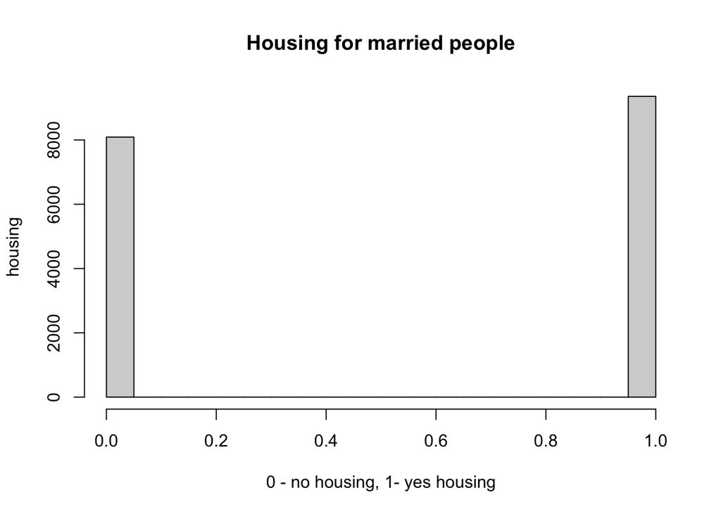

```r
hist(married_people$housing,main='Housing for married people', xlab='0 - no housing, 1- yes housing', ylab='housing')
```

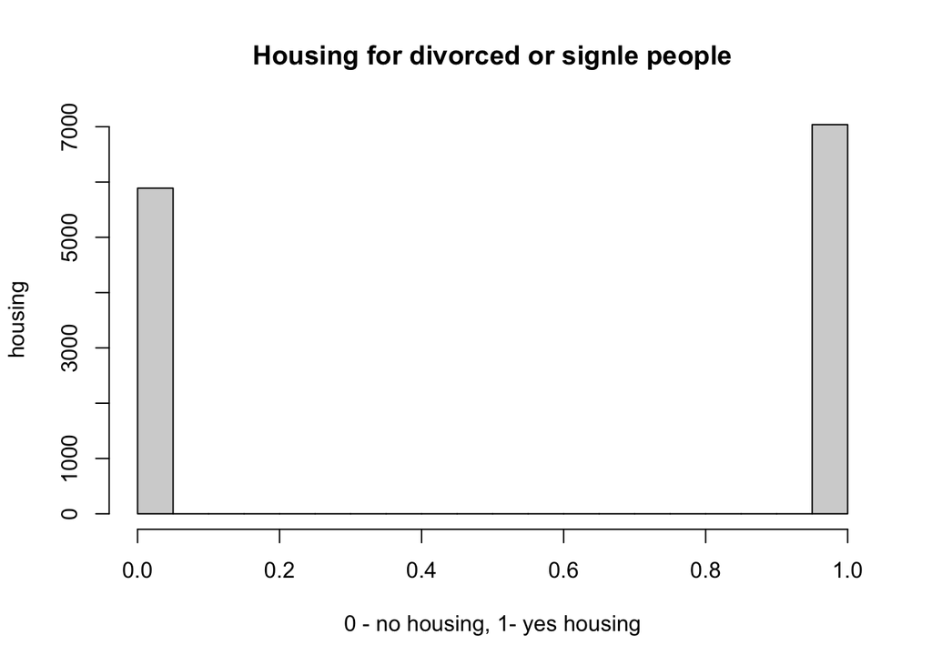

```r
hist(divorced_and_single_people$housing,main='Housing for divorced or signle people', xlab='0 - no housing, 1- yes housing', ylab='housing')
```

Po danim grafovima i po izračunatim srednjim vrijednostima ne vidimo neke značajne razlike ni za stambeni kredit, pa za sad nećemo ništa posebno zaključivati za odnos ženidbenog statusa i privantog kredita.

EDUKACIJA

Podjela ispitanika u ovisnosti o završenom statusu edukacije:

```r
primary_school = BankData[which(BankData$education == 1 | BankData$education == 2 | BankData$education == 3),]
high_school = BankData[which(BankData$education == 4),]
university = BankData[which(BankData$education == 7),]
illiterate = BankData[which(BankData$education == 5),]
```

Pirvatni kredit u ovisnosti o edukaciji:

```r
cat('Prosjek ljudi sa završenom samo osnovnom školom koji imaju privatni kredit ', mean(primary_school$loan), '\n')
```

```
## Prosjek ljudi sa završenom samo osnovnom školom koji imaju privatni kredit  0.1515073
```

```r
cat('Prosjek ljudi sa završenom srednjom školom koji imaju privatni kredit ', mean(high_school$loan), '\n')
```

```
## Prosjek ljudi sa završenom srednjom školom koji imaju privatni kredit  0.1551371
```

```r
cat('Prosjek ljudi sa završenim fakulteteom koji imaju privatni kredit ', mean(university$loan), '\n')
```

```
## Prosjek ljudi sa završenim fakulteteom koji imaju privatni kredit  0.1613934
```

```r
cat('Prosjek nepismenih ljudi koji imaju privatni kredit ', mean(illiterate$loan), '\n')
```

```
## Prosjek nepismenih ljudi koji imaju privatni kredit  0.147007
```

Histogram za edukaciju i privatni kredit:

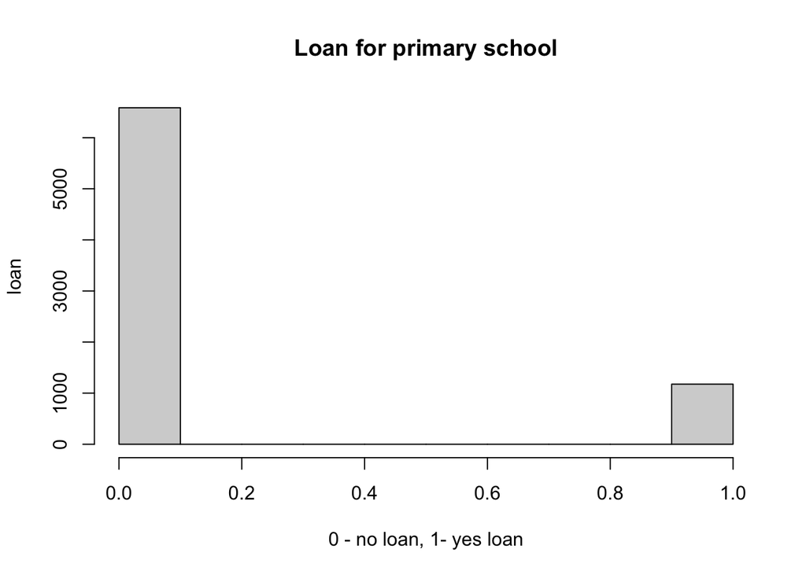

```r
hist(primary_school$loan,main='Loan for primary school', xlab='0 - no loan, 1- yes loan', ylab='loan')
```

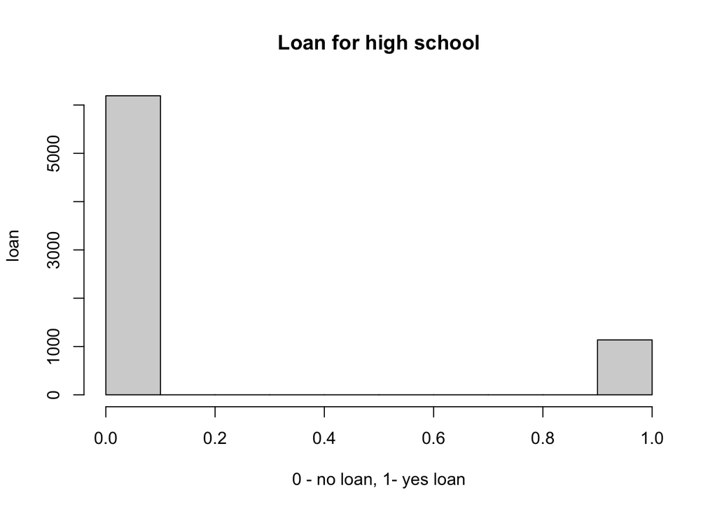

```r
hist(high_school$loan,main='Loan for high school', xlab='0 - no loan, 1- yes loan', ylab='loan')
```

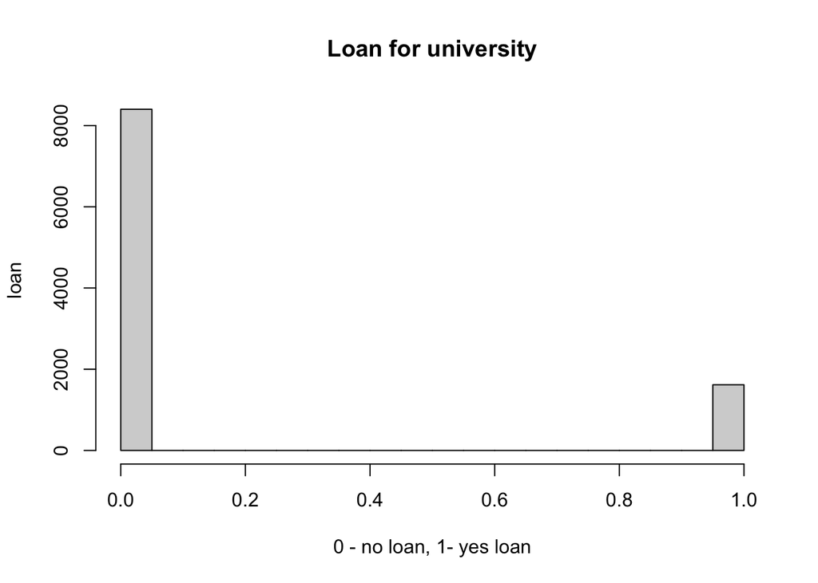

```r
hist(university$loan,main='Loan for university', xlab='0 - no loan, 1- yes loan', ylab='loan')
```

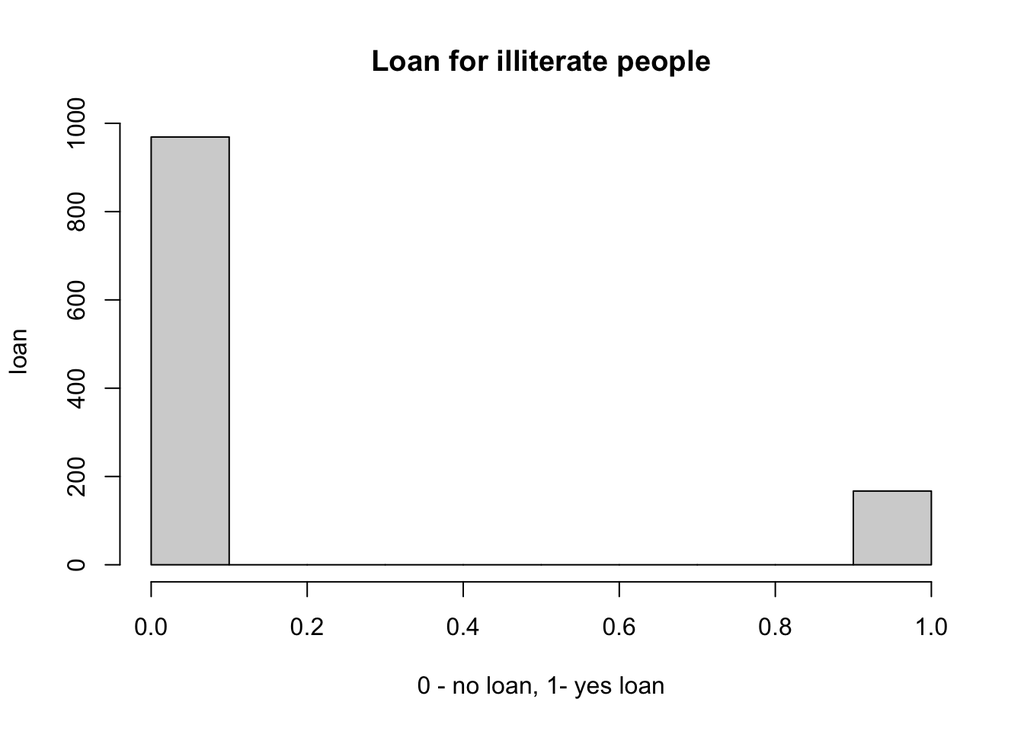

```r
hist(illiterate$loan,main='Loan for illiterate people', xlab='0 - no loan, 1- yes loan', ylab='loan')
```

Po danim grafovima i po izračunatim srednjim vrijednostima ne vidimo neke značajne razlike, pa za sad nećemo ništa posebno zaključivati za odnos edukacije i privantog kredita. Stambeni kredit u ovisnosti o edukaciji:

```r
cat('Prosjek ljudi sa završenom samo osnovnom školom koji imaju stambeni kredit ', mean(primary_school$housing), '\n')
```

```
## Prosjek ljudi sa završenom samo osnovnom školom koji imaju stambeni kredit  0.5324659
```

```r
cat('Prosjek ljudi sa završenom srednjom školom koji imaju stambeni kredit ', mean(high_school$housing), '\n')
```

```
## Prosjek ljudi sa završenom srednjom školom koji imaju stambeni kredit  0.5284486
```

```r
cat('Prosjek ljudi sa završenim fakulteteom koji imaju stambeni kredit ', mean(university$housing), '\n')
```

```
## Prosjek ljudi sa završenim fakulteteom koji imaju stambeni kredit  0.5483581
```

```r
cat('Prosjek nepismenih ljudi koji imaju stambeni kredit ', mean(illiterate$housing), '\n')
```

```
## Prosjek nepismenih ljudi koji imaju stambeni kredit  0.5202465
```

Histogram za edukaciju i stambeni kredit:

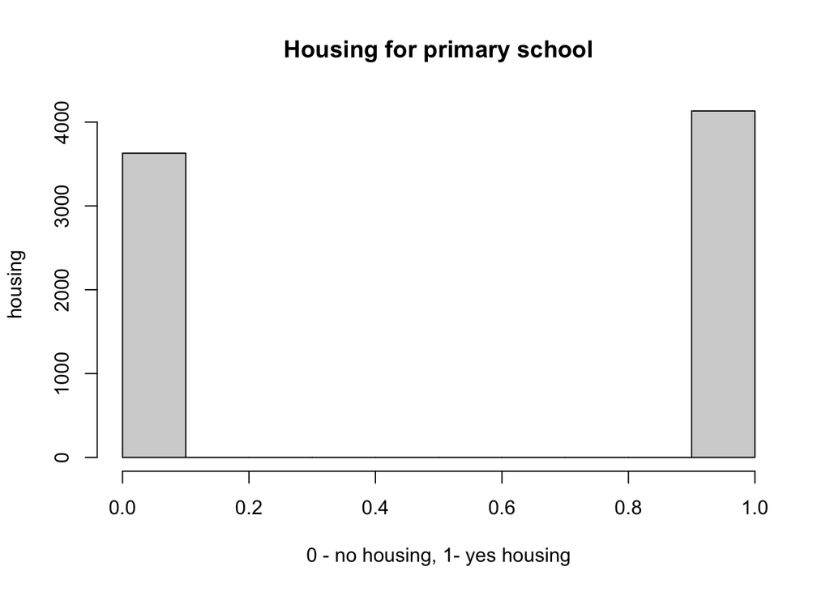

```r
hist(primary_school$housing,main='Housing for primary school', xlab='0 - no housing, 1- yes housing', ylab='housing')
```

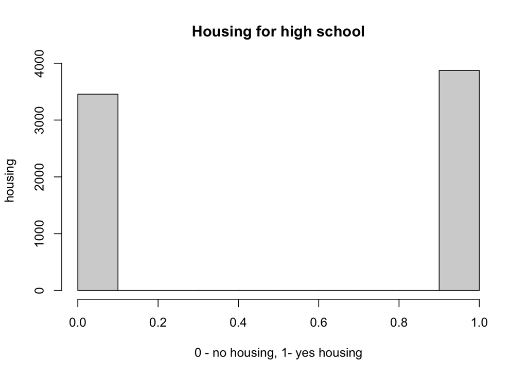

```r
hist(high_school$housing,main='Housing for high school', xlab='0 - no housing, 1- yes housing', ylab='housing')
```

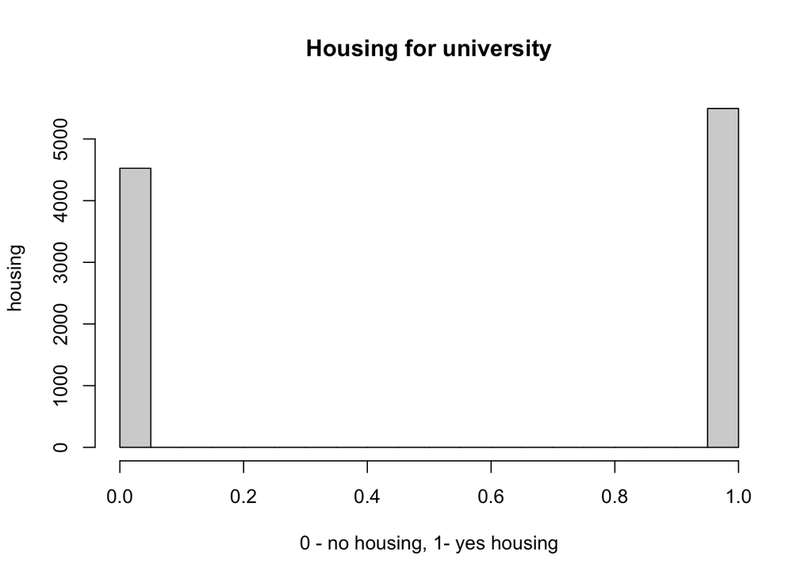

```r
hist(university$housing,main='Housing for university', xlab='0 - no housing, 1- yes housing', ylab='housing')
```

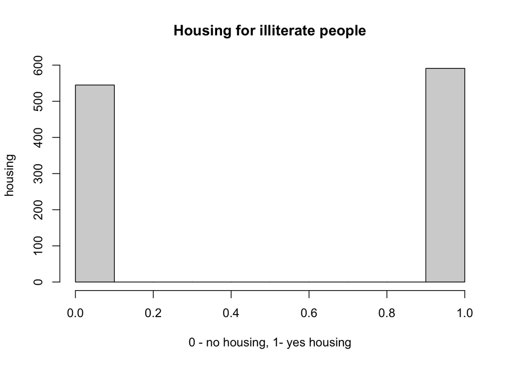

```r
hist(illiterate$housing,main='Housing for illiterate people', xlab='0 - no housing, 1- yes housing', ylab='housing')
```

Po danim grafovima i po izračunatim srednjim vrijednostima ne vidimo neke značajne razlike ni za stambeni kredit, pa za sad nećemo ništa posebno zaključivati za odnos edukacije i stambenog kredita.

CPI - Consumer Price Index

CPI je mjera koliko proizvoda se u prosjeku stavlja u košatricu.

Nakon što smo pogledali ovisnosti dviju vrsta kredita s godinama, edukacijom i bračnim statusom, i nismo pronašli neke pametne rezultate, pogledat ćemo CPI i kako se on kreće u ovisnosti o nekim varijablama.

Za početak ćemo prikazati histogram za CPI za cijeli skup podataka.

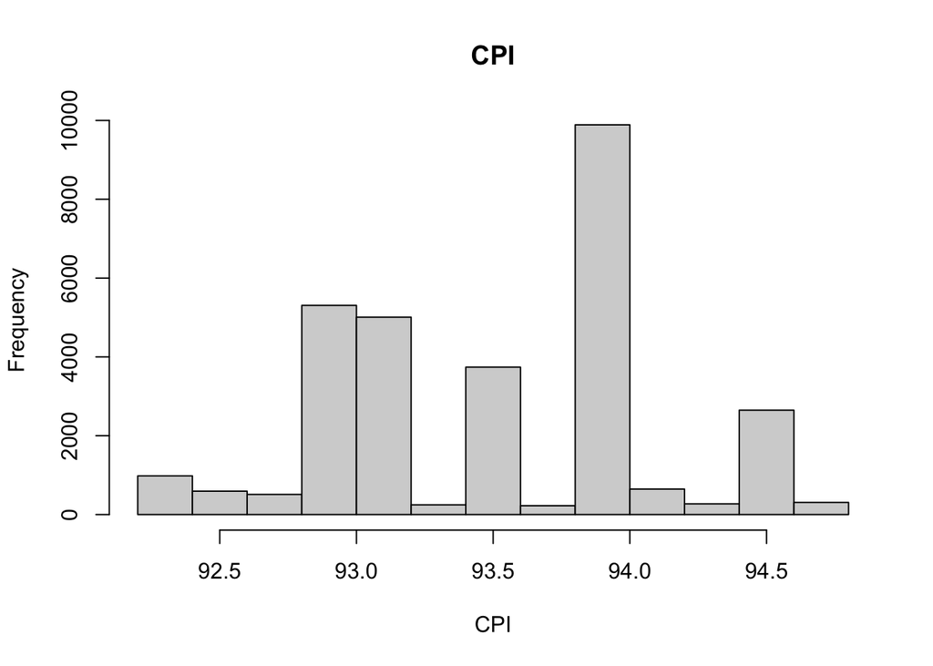

```r
hist(BankData$cons.price.idx,main='CPI', xlab='CPI', ylab='Frequency')
```

Sada imamo pregled CPI, ali nam on ne predstavlja ništa pametno, pa ćCemo gledati CPI u ovisnosti o godinama, bračnom statusu i edukaciji.

CPI i godine:

Prosjeci po godinama za CPI:

```r
cat('Prosječni CPI mladih ljudi ', mean(young$cons.price.idx), '\n')
```

```
## Prosječni CPI mladih ljudi  93.07497
```

```r
cat('Prosječni CPI srednje starih ljudi', mean(middle$cons.price.idx), '\n')
```

```
## Prosječni CPI srednje starih ljudi 93.51258
```

```r
cat('Prosječni CPI starijih ljudi ', mean(old$cons.price.idx), '\n')
```

```
## Prosječni CPI starijih ljudi  93.52642
```

```r
cat('Prosječni CPI za sve ispitanike', mean(BankData$cons.price.idx))
```

```
## Prosječni CPI za sve ispitanike 93.51981
```

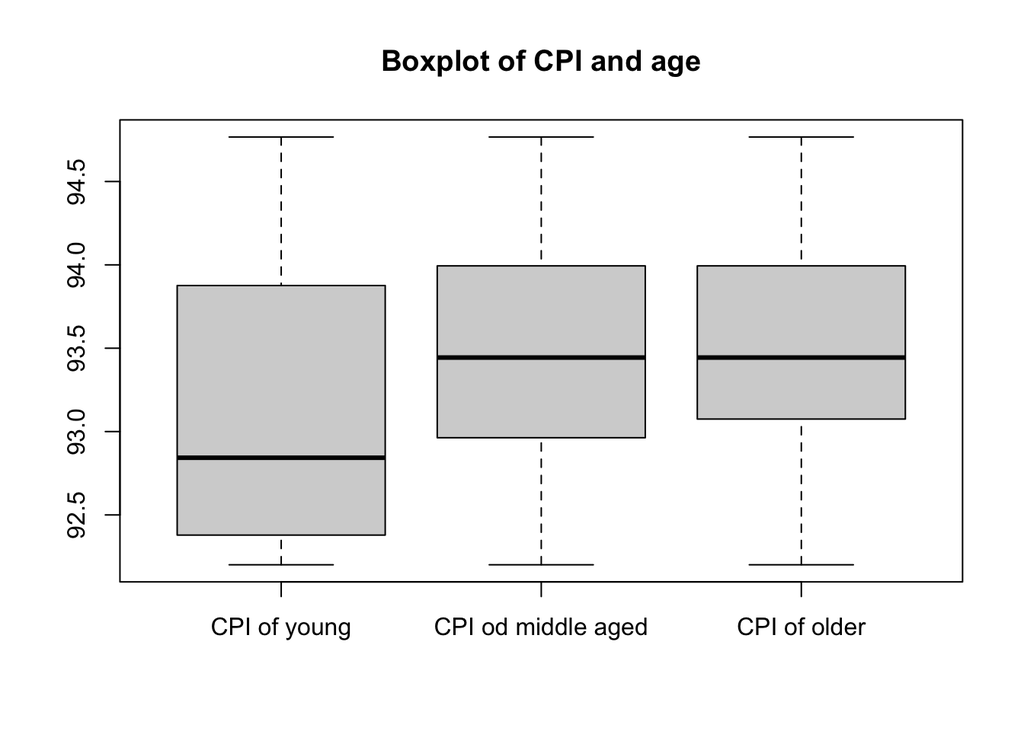

```r
boxplot(young$cons.price.idx, middle$cons.price.idx,old$cons.price.idx,
        names = c('CPI of young','CPI od middle aged', 'CPI of older'),
        main = 'Boxplot of CPI and age')
```

Gledajući samo prosjeke, ne vuidimo veliku razliku, ali gledajući box plot možemo vidjeti da je ICP manji kod mlađih ljudi. To ima smisla, jer je mladđim ljudima kupovna moć manja..

CPI i edukacija:

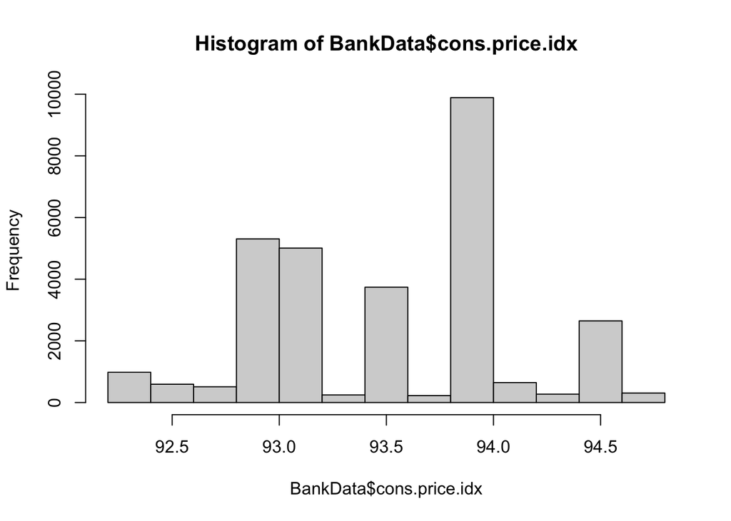

```r
hist(BankData$cons.price.idx)
```

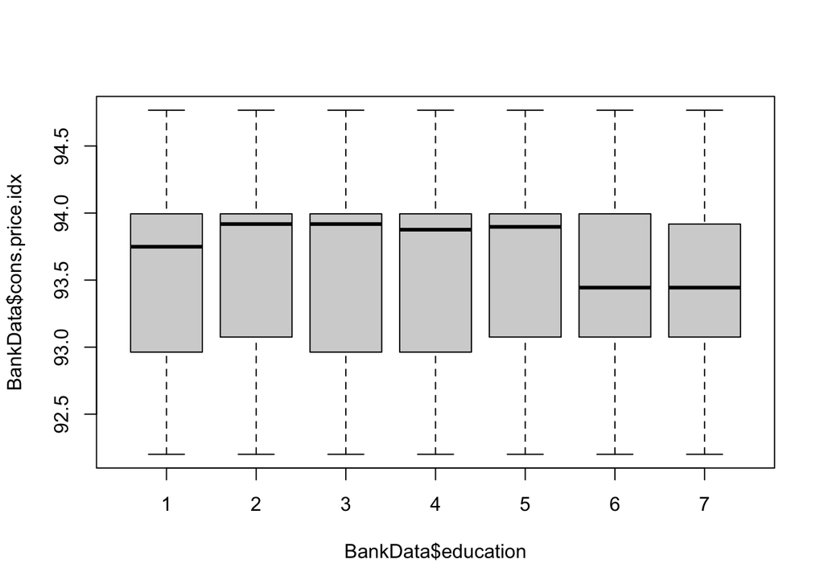

```r
boxplot(BankData$cons.price.idx~BankData$education)
```

Prosjeci po edukaciji za CPI:

```r
cat('Prosječni CPI ljudi sa završenom samo osnovnom školom ', mean(primary_school$cons.price.idx), '\n')
```

```
## Prosječni CPI ljudi sa završenom samo osnovnom školom  93.5634
```

```r
cat('Prosječni CPI ljudi sa završenom srednjom školom', mean(high_school$cons.price.idx), '\n')
```

```
## Prosječni CPI ljudi sa završenom srednjom školom 93.54573
```

```r
cat('Prosječni CPI ljudi sa završenim fakultetom ', mean(university$cons.price.idx), '\n')
```

```
## Prosječni CPI ljudi sa završenim fakultetom  93.45742
```

```r
cat('Prosječni CPI nepismenih ljudi', mean(illiterate$cons.price.idx))
```

```
## Prosječni CPI nepismenih ljudi 93.55392
```

Boxplot za prosjek CPI s obzirom na razinu edukacije:

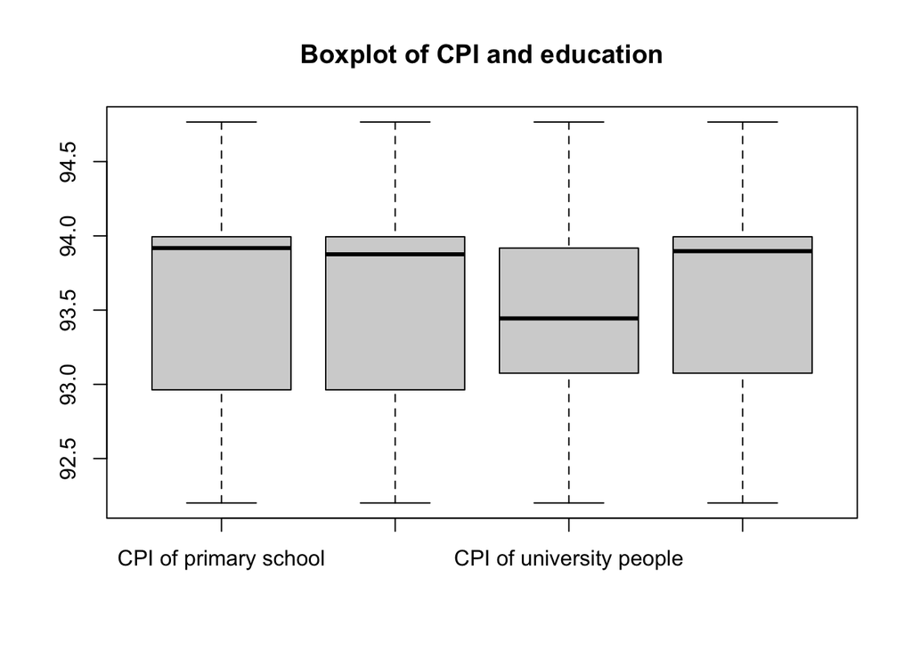

```r
boxplot(primary_school$cons.price.idx, high_school$cons.price.idx,university$cons.price.idx, illiterate$cons.price.idx,
        names = c('CPI of primary school','CPI od high school', 'CPI of university people', 'CPI of illiterate people'),
        main = 'Boxplot of CPI and education')
```

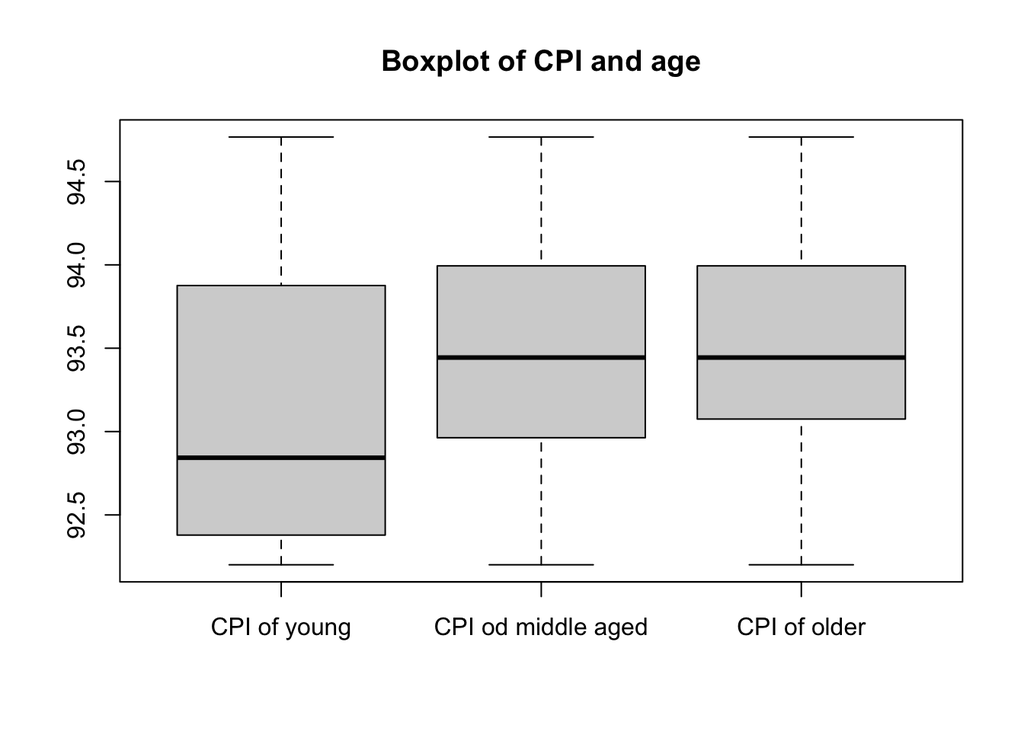

```r
boxplot(young$cons.price.idx, middle$cons.price.idx,old$cons.price.idx,
        names = c('CPI of young','CPI od middle aged', 'CPI of older'),
        main = 'Boxplot of CPI and age')
```

CPI i bračni status

- 1 = rastavljen / a
- 2 = oženjen / udana
- 3 = slobodan / slobodna

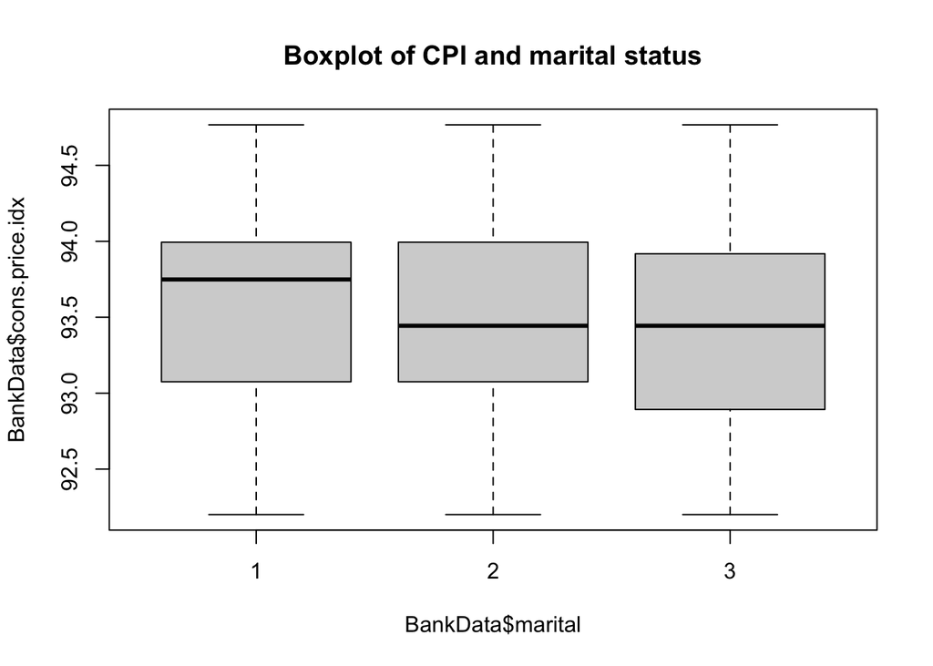

```r
boxplot(BankData$cons.price.idx~BankData$marital,
        main = 'Boxplot of CPI and marital status')
```